# Welcome to RStudio! IDE Overview & Setup

January 15, 2024 @ 02:41 PM

## Welcome Everyone!

[figure not shown]

## A Note on Images

Many of the images are quick screengrabs and may look less than their best resolution when reduced in size. You can right-click (or the Mac equivalent) on any image to open it to its full size or to save it to your own computer.

Now let’s explore! Log into your [ASU Rstudio server](https://mathr.math.appstate.edu/) account.

## What are R and RStudio?

- `R` is a programming language that runs computations
- RStudio is an integrated development environment (IDE) — a user interface that makes it easier for us to interact with `R`

[figure not shown]

Analogy of the difference between `R` and RStudio (from [Modern Dive](https://moderndive.com/1-getting-started.html#r-rstudio))

## The RStudio ([Posit](https://posit.co/)) IDE

An integrated development environment (IDE) is software that combines common tools into a single graphical user interface (GUI). Common components include:

- A text editor with features such as syntax highlighting, auto-completion, and checking for bugs.
- Utilities that automate simple, repeatable tasks.
- A program for testing code to find bugs.

RStudio isn’t the only IDE for R, but it is one of the most widely used. Like the textbook [Modern Dive](https://moderndive.com/1-getting-started.html) says, R is like the engine and RStudio is the dashboard that lets us drive the car. We can also add packages to “soup up” our engine.

## The Power of R and RStudio…

[figure not shown]

The slides you’re looking at right now were created in RStudio using R Markdown that was “knitted” into standalone HTML.

Many of our online textbooks were produced the same way!

## When you First Log In…

Your RStudio server will look something like this, except your Console pane (*what is that, you ask?*) will be on the left.

[figure not shown]

## RStudio’s Four Panes

There are four “[panes](https://teacherscollege.screenstepslive.com/a/1426910-panes-in-rstudio)” in the RStudio interface.

- Console pane (this is the R engine)
- Environment pane
- Files/Plots/Packages/Help pane
- [Source Editor](https://support.rstudio.com/hc/en-us/articles/207126217-Using-Source-Windows-in-the-RStudio-IDE) (coding/document) pane

You can rearrange these panes to suit your own preferences. We will talk more about that shortly…

The first time you log into the RStudio server, you will not have a **Source Editor**. We will talk about how to create new code scripts and R Markdown documents for you to code in.

## Pane Functions in Brief

[figure not shown]

The four panes of RStudio (from [YaRrr! The Pirate’s Guide to R](https://bookdown.org/ndphillips/YaRrr/the-four-rstudio-windows.html))

## Where is the Source Pane?

After we open a script or R Markdown file to edit code, you will see all four panes. The default position is the upper left corner.

[figure not shown]

## Opening a Source File

This menu is much like any windows program — **File** > **New File**.

[figure not shown]

## Script File

The file extension on an **script** is .R, but it is just a plain text file. Notice the set of options in the pane’s menu bar.

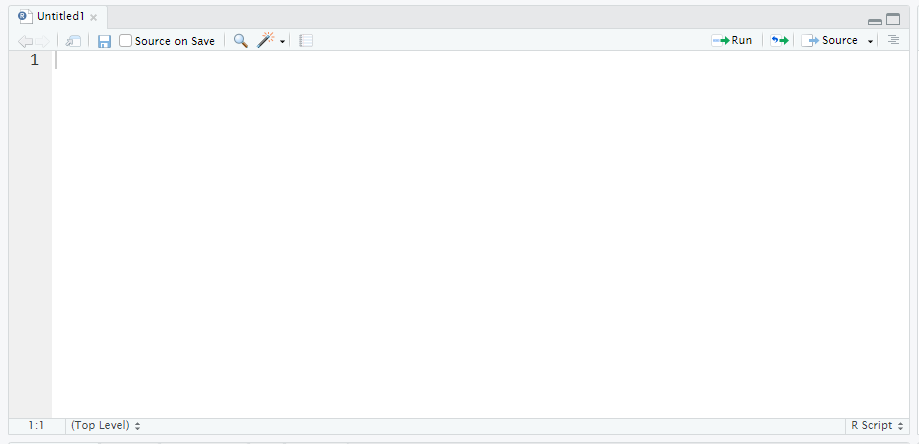

## Script File Toolbar Options

- show in new window
- save
- Source on Save
- Find/Replace
- Code Tools
- Compile Report
- Run
- Rerun previous code region
- Go to previous section/chunk
- Go to next section/chunk
- Source

## R Markdown File

The file extension is .Rmd, but it is also basically just a plain text file. The difference is in the processing. Notice the options in the pane’s menu bar—they are different than a script.

[figure not shown]

## R Markdown Toolbar Options

- show in new window
- save
- Knit on Save
- Check spelling in document
- Find/Replace
- Knit
- Tools (gear icon)
- Insert a new code chunk
- Go to previous/next section/chunk
- Run
- Publish document

## Dr. Thomley’s ongoing battle…

[figure not shown]

## Choices, choices, choices…

[figure not shown]

## Quarto File

[Quarto](https://quarto.org/) is a free and open-source scientific / technical publishing system. From its [website](https://quarto.org/docs/computations/r.html)…

*“Quarto is a multi-language, next generation version of R Markdown from RStudio, with many new features and capabilities. Like R Markdown, Quarto uses Knitr to execute R code, and is therefore able to render most existing Rmd files without modification.”*

Quarto also integrates with Python (plus other languages) and a popular IDE from [Jupyter](https://jupyter.org/).

We are primarily going to use **R Markdown** documents in this class. If you learn that, then you’ll be equipped to expand your skills later. That’s one big fact of data science: you never stop learning because it never stops evolving (and quickly)!

**One of our goals in STT 2860 will be to learn *how* to learn…**

[figure not shown]

## Customizing the Setup

We will set some options that make RStudio work better for us in our class environment. You will find the menu under **Tools > Global Options**. (Also open [Customizing the RStudio IDE](https://support.rstudio.com/hc/en-us/articles/200549016-Customizing-the-RStudio-IDE).)

[figure not shown]

## Editor Theme

You can change the editor [theme](https://support.rstudio.com/hc/en-us/articles/115011846747-Using-Themes-in-the-RStudio-IDE) and font size in RStudio to the settings that are most effective for you.

The different colors in the Source pane are intended to help you code by visually distinguishing different parts of the code.

For example, functions will be one color and strings of text that are inside quotation marks will be another color. Text formatting like italics also will be a different color.

Go to **Tools > Global Options > Appearance** in the toolbar.

```
I like a dark theme with somewhat muted colors called "Tomorrow Night".
```

## Appearance / Theme

Choose a theme you like. You can also change your font size.

[figure not shown]

## Changing Pane Layout

I like my Console to be on the upper right, so I can maximize the Source and Console panes at the same time, and so code “flows” left to right. You can choose what works for you.

[figure not shown]

## **Tools > Global Options > General (Basic)**

The most important thing to do here is **unclick** “Restore .Rdata into workspace at startup” and also change “Save workspace…” to **Never**. Failing to do this can cause issues with your account.

[figure not shown]

## Code Settings in the IDE

Many of the settings are intended to make programming easier.

- How features like the cursor behave
- Suggestions and auto-completion for code
- Multi-colored parenthesis to help with matching
- Additional styling suggestions for enhancing readability

As your data science skills evolve, you may want to adjust your RStudio settings.

Finding what works best *for you* requires some trial and error.

## **Tools > Global Options > Code (Editing)**

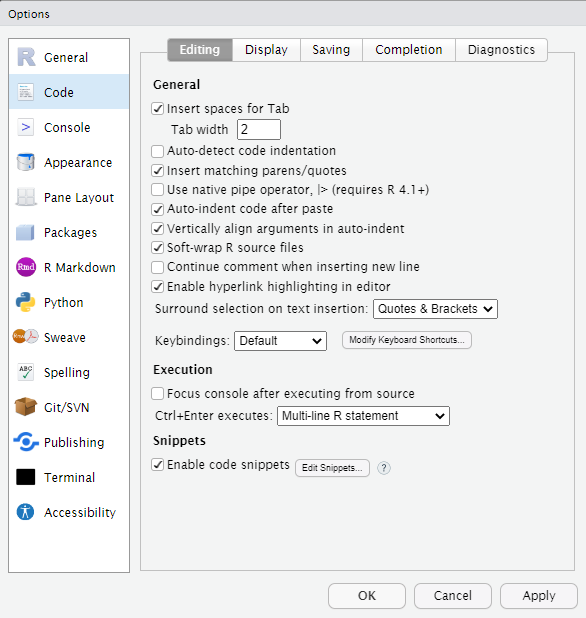

## **Tools > Global Options > Code (Display)**

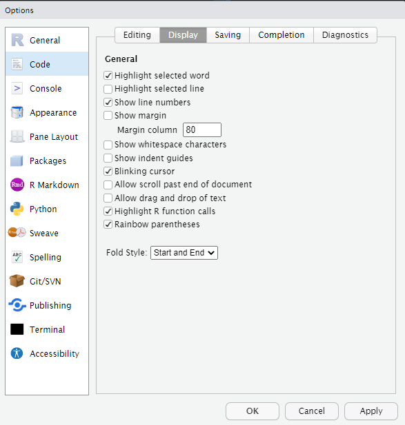

## **Tools > Global Options > Code (Saving)**

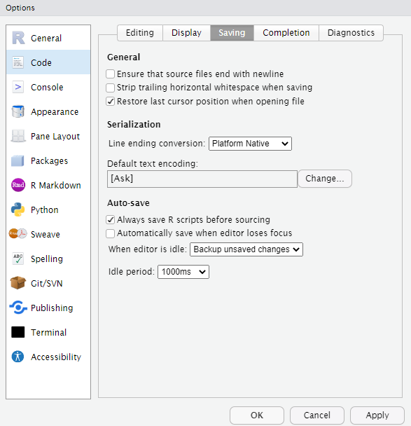

## **Tools > Global Options > Code (Comp.)**

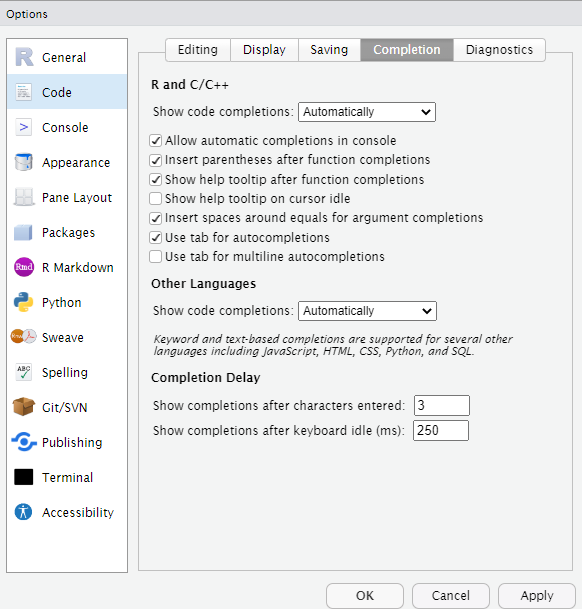

## **Tools > Global Options > Code (Diag.)**

[figure not shown]

## Code Menu

`Comment/Uncomment Lines` and `Reindent Lines` are helpful!

[figure not shown]

## Session Menu

Sometimes when `R` is behaving in an inexplicable way, you may need to save your work and restart your `R` session. Yes…this is basically turn it off and back on again ;)

[figure not shown]

## Help Menu

There are several “cheat sheets” available. You can also view all the keyboard shortcuts here, get help with simple R Markdown formatting, or turn on accessibility options.

[figure not shown]

At first, things might feel a little like this…

[figure not shown]

But I can tell you from past experience that most folks succeed in STT 2860 if they come and engage with an open mind.

[figure not shown]

## References

[Command History in the RStudio IDE](https://support.rstudio.com/hc/en-us/articles/200526217)

[Customizing the RStudio IDE](https://support.rstudio.com/hc/en-us/articles/200549016-Customizing-the-RStudio-IDE)

[Editing and Executing Code in the RStudio IDE](https://support.rstudio.com/hc/en-us/articles/200484448-Editing-and-Executing-Code-in-the-RStudio-IDE)

[Keyboard Shortcuts in the RStudio IDE](https://support.rstudio.com/hc/en-us/articles/200711853-Keyboard-Shortcuts-in-the-RStudio-IDE)

[Panes in RStudio](https://teacherscollege.screenstepslive.com/a/1426910-panes-in-rstudio)

[Working in the Console in the RStudio IDE](https://support.rstudio.com/hc/en-us/articles/200404846-Working-in-the-Console-in-the-RStudio-IDE)

Cartoon illustrations: [Artwork by @allison_horst](https://allisonhorst.com/allison-horst)